# Northern Hemisphere

David Meza

8/1/2017

Read the data from my folder

```r
NHtemp <- read_csv("~/OneDrive/GitHub/NASADatanauts/data/NHtemp.csv",
                    na = "empty", comment = "*")
```

Pull out the monthly data for each year. Removing 2017 since it has missing data. Tidy the data, gather the months and mean temperatures into columns. Arrange the data by year, ascending. The month means for 1880 - 2016

```r
NHyearlyTemp <- NHtemp %>%
    select(Year:Dec) %>%
    filter(Year != 2017) %>%
    gather(Months, MeanTemp, -Year) %>%
    arrange(Year)
```

### The summer month means for 1880 - 2016

```r
NHsummerTemp <- NHtemp %>%
    select(Year, Jun:Aug) %>%
    filter(Year != 2017) %>%
    gather(Months, MeanTemp, -Year) %>%
    arrange(Year)
```

Adding a column for the Year groups. This will be used as the frame parameter for the animation, shown below.

```r
NHsummerTemp <- data.table(NHsummerTemp)
NHsummerTemp[, Group := ifelse(Year %in% c(1951:1980), "1951-1980",
                               ifelse(Year %in% c(1983:1993), "1983-1993",
                               ifelse(Year %in% c(1994:2004), "1994-2004",
                               ifelse(Year %in% c(2005:2015), "2005-2015", "1880-1950"))))]
```

The base period is 1951 - 1980. Let’s pull that out to create the base plot. Just to show you what the yearly and summer month means loook like.

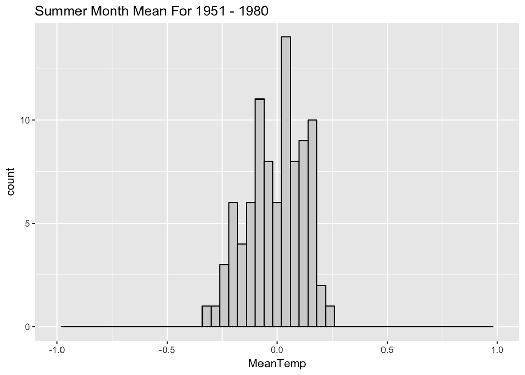

```r
ggplot(data = filter(NHsummerTemp, between(Year, 1951, 1980)), mapping = aes(MeanTemp))  +
    geom_histogram(binwidth = 0.04, fill = "light gray", color = "black") +
    xlim(-1, 1) +
    ggtitle("Summer Month Mean For 1951 - 1980")
```

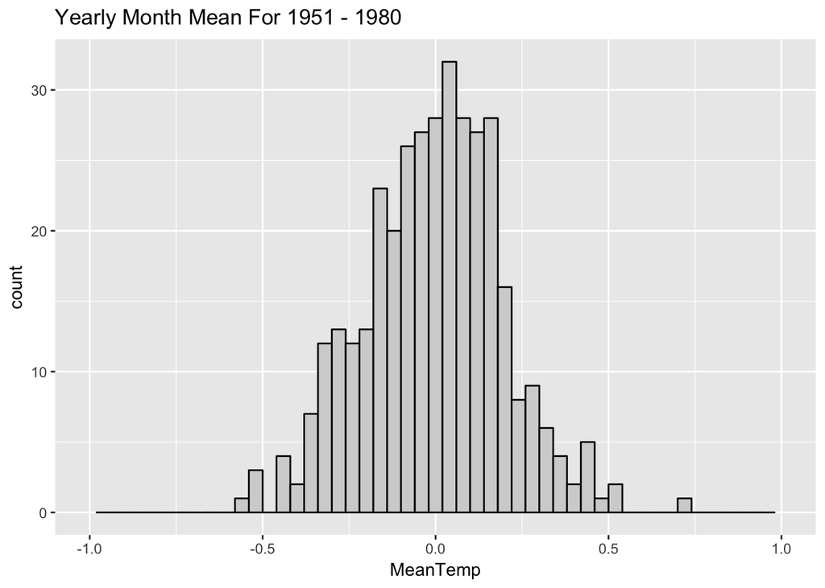

```r
ggplot(data = filter(NHyearlyTemp, between(Year, 1951, 1980)), mapping = aes(MeanTemp))  +
    geom_histogram(binwidth = 0.04, fill = "light gray", color = "black") +
    xlim(-1, 1) +
    ggtitle("Yearly Month Mean For 1951 - 1980")
```

## For period is 1983 - 1993.

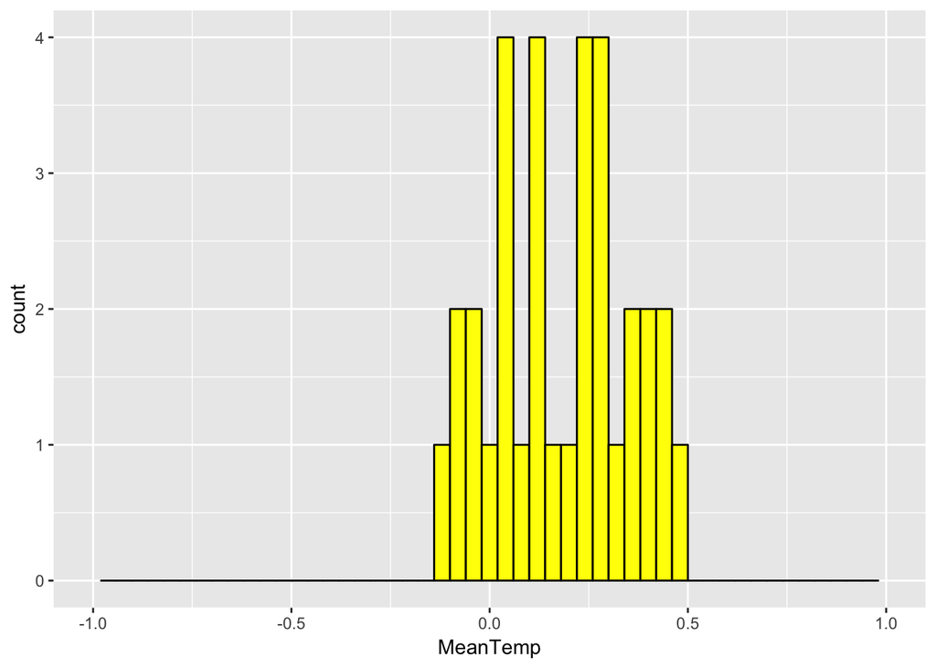

```r
ggplot(data = filter(NHsummerTemp, between(Year, 1983, 1993)), mapping = aes(MeanTemp))  +
    geom_histogram(binwidth = 0.04, fill = "yellow", color = "black") +
    xlim(-1, 1)
```

## The period is 1994 - 2004.

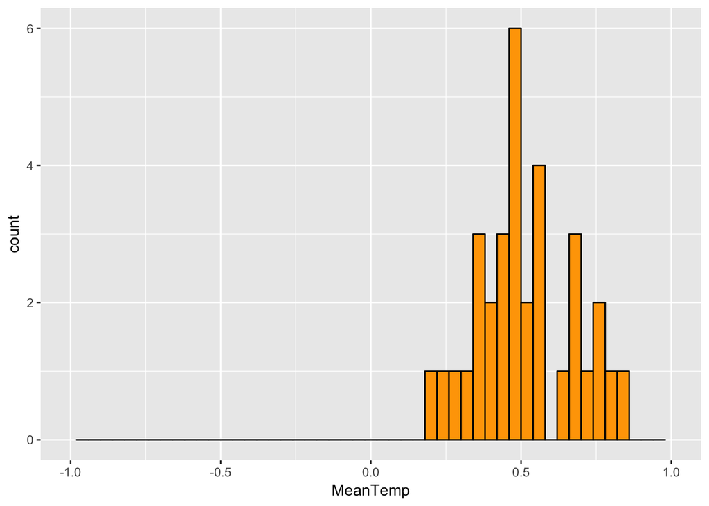

```r
ggplot(data = filter(NHsummerTemp, between(Year, 1994, 2004)), mapping = aes(MeanTemp))  +
    geom_histogram(binwidth = 0.04, fill = "orange", color = "black") +
    xlim(-1, 1)
```

## The period is 2005 - 2015.

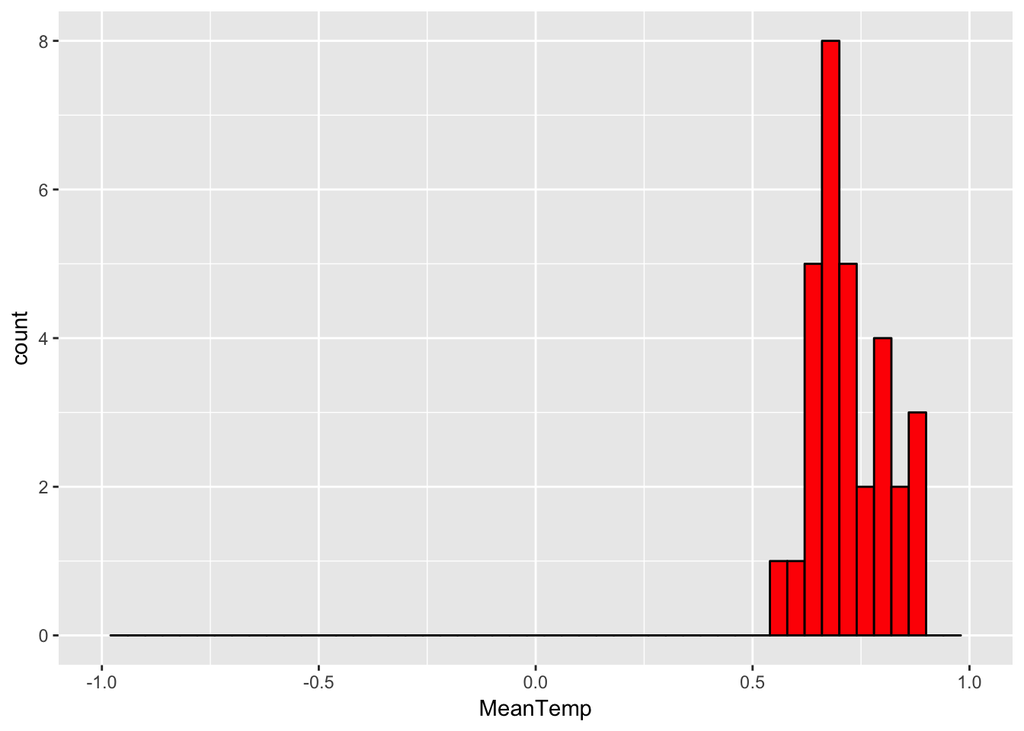

```r
ggplot(data = filter(NHsummerTemp, between(Year, 2005, 2015)), mapping = aes(MeanTemp))  +
    geom_histogram(binwidth = 0.04, fill = "red", color = "black") +
    xlim(-1, 1)
```

I wanted to see the table of means for the years. I do not use it anywhere else

```r
x <- filter(NHsummerTemp, between(Year, 1951, 1980))
table(x$MeanTemp)
```

```
##
##  -0.3 -0.26 -0.24 -0.22 -0.21  -0.2 -0.19 -0.18 -0.17 -0.14 -0.13 -0.12
##     1     1     1     2     1     2     2     1     1     3     2     2
## -0.11  -0.1 -0.09 -0.08 -0.07 -0.06 -0.05 -0.04 -0.03 -0.02     0  0.01
##     1     1     3     2     4     2     2     4     1     1     2     2
##  0.02  0.03  0.04  0.05  0.06  0.07  0.08  0.09   0.1  0.11  0.12  0.13
##     2     3     2     4     5     4     1     2     1     2     3     2
##  0.14  0.16  0.17  0.18   0.2  0.21  0.23
##     2     4     2     4     1     1     1
```

This plots all the histograms on one canvass. `ggplot()` creates a canvas. You can add data and aesthetics `(aes)` here or set them in the geometric, i.e., `geom_histogram`.

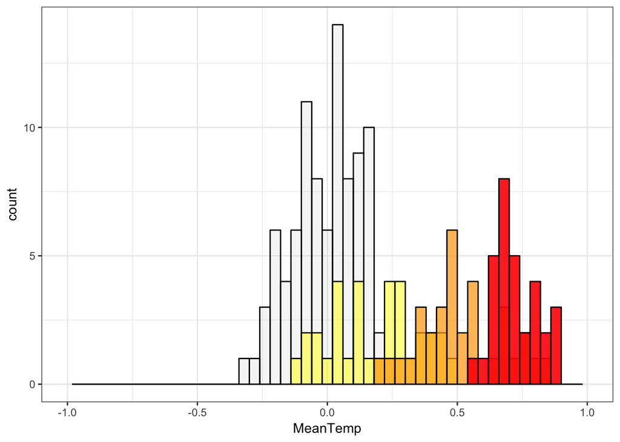

```r
theme_set(theme_bw())
ggplot()  +
    geom_histogram(data = filter(NHsummerTemp, between(Year, 1951, 1980)), mapping = aes(MeanTemp),
                  binwidth = 0.04, fill = "light gray", color = "black", alpha = .2) +
    geom_histogram(data = filter(NHsummerTemp, between(Year, 1983, 1993)), mapping = aes(MeanTemp),
                   binwidth = 0.04, fill = "yellow", color = "black", alpha = .5) +
    geom_histogram(data = filter(NHsummerTemp, between(Year, 1994, 2004)), mapping = aes(MeanTemp),
                   binwidth = 0.04, fill = "orange", color = "black", alpha = .7) +
    geom_histogram(data = filter(NHsummerTemp, between(Year, 2005, 2015)), mapping = aes(MeanTemp),
                   binwidth = 0.04, fill = "red", color = "black", alpha = .9) +
    xlim(-1, 1)
```

This package require [ImageMagick](http://imagemagick.org/script/index.php) on your system. [gganimate github site](https://github.com/dgrtwo/gganimate)

`df` is used as the data source for the histograms used in the animation. The first `geom_histogram` uses a different data source. This is the base plot.

```r
df <- filter(NHsummerTemp, between(Year, 1983, 2015))
p <- ggplot(data = df, mapping = aes(MeanTemp))  +
    geom_histogram(data = filter(NHsummerTemp, between(Year, 1951, 1980)), mapping = aes(MeanTemp),
                   binwidth = 0.04, fill = "light gray", color = "black", alpha = .2) +
    geom_histogram(aes(frame = Group, fill = Group),binwidth = 0.04, color = "black") +
    xlim(-1, 1)

gganimate(p, interval = 1.5)
```

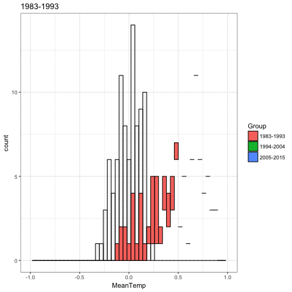

Northern Hemisphere Temps